# EDA Analysis of a dataset

## File name: Drug overdose deaths (Accidental drug related deaths during 2012-2018)

**Description:** El dataset cuenta con 5105 observaciones y 42 variables (17 de ellas relacionadas con el tipo de droga consumida), otras variables se centran en características biológicas como Sexo, Edad o Raza y por otra parte existen otras variables que se centran en el lugar de la muerte y de la residencia de la persona.

**Link dataset:** https://www.kaggle.com/ruchi798/drug-overdose-deaths

**Source_1:** https://towardsdatascience.com/exploratory-data-analysis-eda-python-87178e35b14#:~:text=EDA%20in%20Python%20uses%20data,which%20can%20have%20repercussions%20later

**Source_2:** https://towardsdatascience.com/exploratory-data-analysis-in-python-c9a77dfa39ce

### 1. Data sourcing and library import

Importamos todo el conjunto de librerías necesarias para poder realizar el análisis exploratorio de nuestro dataset. Utilizaremos principalmente las librerías de Numpy, Panda, Matplotlib y Seaborn.

```python
import numpy as np
import pandas as pd
import matplotlib as mpl
import seaborn as sns
import matplotlib.pyplot as plt
```

Importamos el dataset y lo nombraremos a partir de ahora como "drug"

```python
drug = pd.read_csv('./drug_deaths.csv', sep = ",")
```

### 2. Data description

En este apartado del trabajo nos centraremos en la mera descripción y exposición del dataset, exponinedo las variables que lo conforman, su significado o el tipo del variable que es.

```python
drug.columns
```

```
Index(['Unnamed: 0', 'ID', 'Date', 'DateType', 'Age', 'Sex', 'Race',
       'ResidenceCity', 'ResidenceCounty', 'ResidenceState', 'DeathCity',
       'DeathCounty', 'Location', 'LocationifOther', 'DescriptionofInjury',
       'InjuryPlace', 'InjuryCity', 'InjuryCounty', 'InjuryState', 'COD',
       'OtherSignifican', 'Heroin', 'Cocaine', 'Fentanyl', 'Fentanyl_Analogue',
       'Oxycodone', 'Oxymorphone', 'Ethanol', 'Hydrocodone', 'Benzodiazepine',
       'Methadone', 'Amphet', 'Tramad', 'Morphine_NotHeroin', 'Hydromorphone',
       'Other', 'OpiateNOS', 'AnyOpioid', 'MannerofDeath', 'DeathCityGeo',
       'ResidenceCityGeo', 'InjuryCityGeo'],
      dtype='object')
```

```python
drug.head(5)
```

|  | Unnamed: 0 | ID | Date | DateType | Age | Sex | Race | ResidenceCity | ResidenceCounty | ResidenceState | ... | Tramad | Morphine_NotHeroin | Hydromorphone | Other | OpiateNOS | AnyOpioid | MannerofDeath | DeathCityGeo | ResidenceCityGeo | InjuryCityGeo |
| --- | --- | --- | --- | --- | --- | --- | --- | --- | --- | --- | --- | --- | --- | --- | --- | --- | --- | --- | --- | --- | --- |
| 0 | 0 | 14-0273 | 06/28/2014 12:00:00 AM | 1.0 | NaN | NaN | NaN | NaN | NaN | NaN | ... | 0 | 0 | 0 | NaN | 0 | 0 | Accident | CT\n(41.575155, -72.738288) | CT\n(41.575155, -72.738288) | CT\n(41.575155, -72.738288) |
| 1 | 1 | 13-0102 | 03/21/2013 12:00:00 AM | 0.0 | 48.0 | Male | Black | NORWALK | NaN | NaN | ... | 0 | 0 | 0 | NaN | 0 | 0 | Accident | Norwalk, CT\n(41.11805, -73.412906) | NORWALK, CT\n(41.11805, -73.412906) | CT\n(41.575155, -72.738288) |
| 2 | 2 | 16-0165 | 03/13/2016 12:00:00 AM | 0.0 | 30.0 | Female | White | SANDY HOOK | FAIRFIELD | CT | ... | 0 | 0 | 0 | NaN | 0 | 1 | Accident | Danbury, CT\n(41.393666, -73.451539) | SANDY HOOK, CT\n(41.419998, -73.282501) | NaN |
| 3 | 3 | 16-0208 | 03/31/2016 12:00:00 AM | 0.0 | 23.0 | Male | White | RYE | WESTCHESTER | NY | ... | 0 | 0 | 0 | NaN | 0 | 1 | Accident | Greenwich, CT\n(41.026526, -73.628549) | NaN | NaN |
| 4 | 4 | 13-0052 | 02/13/2013 12:00:00 AM | 0.0 | 22.0 | Male | Asian, Other | FLUSHING | QUEENS | NaN | ... | 0 | 0 | 0 | NaN | 0 | 0 | Accident | Greenwich, CT\n(41.026526, -73.628549) | NaN | CT\n(41.575155, -72.738288) |

5 rows × 42 columns

```python
drug.tail(5)
```

|  | Unnamed: 0 | ID | Date | DateType | Age | Sex | Race | ResidenceCity | ResidenceCounty | ResidenceState | ... | Tramad | Morphine_NotHeroin | Hydromorphone | Other | OpiateNOS | AnyOpioid | MannerofDeath | DeathCityGeo | ResidenceCityGeo | InjuryCityGeo |
| --- | --- | --- | --- | --- | --- | --- | --- | --- | --- | --- | --- | --- | --- | --- | --- | --- | --- | --- | --- | --- | --- |
| 5100 | 5100 | 15-0466 | 09/08/2015 12:00:00 AM | 1.0 | 43.0 | Male | White | CHESHIRE | NEW HAVEN | CT | ... | 0 | 0 | 0 | NaN | 0 | 0 | Accident | CHESHIRE, CT\n(41.498834, -72.901448) | CHESHIRE, CT\n(41.498834, -72.901448) | CT\n(41.575155, -72.738288) |
| 5101 | 5101 | 17-0618 | 07/22/2017 12:00:00 AM | 1.0 | 21.0 | Male | White | MADISON | NEW HAVEN | CT | ... | 0 | 0 | 0 | NaN | 0 | 0 | Accident | New Haven, CT\n(41.308252, -72.924161) | MADISON, CT\n(41.271447, -72.60086) | CT\n(41.575155, -72.738288) |
| 5102 | 5102 | 18-0646 | 08/14/2018 12:00:00 AM | 0.0 | 30.0 | Male | White | LAWRENCEVILLE | TIOGA | PA | ... | 1 | 0 | 0 | NaN | 0 | 1 | Accident | DANBURY, CT\n(41.393666, -73.451539) | NaN | DANBURY, CT\n(41.393666, -73.451539) |
| 5103 | 5103 | 14-0124 | 03/16/2014 12:00:00 AM | 0.0 | 33.0 | Male | White | HARTFORD | NaN | NaN | ... | 0 | 0 | 0 | NaN | 0 | 0 | Accident | WINDSOR, CT\n(41.852781, -72.64379) | HARTFORD, CT\n(41.765775, -72.673356) | CT\n(41.575155, -72.738288) |
| 5104 | 5104 | 16-0637 | 09/15/2016 12:00:00 AM | 0.0 | 33.0 | Male | White | THOMASTON | LITCHFIELD | CT | ... | 0 | 0 | 0 | NaN | 0 | 1 | Accident | WATERBURY, CT\n(41.554261, -73.043069) | THOMASTON, CT\n(41.674124, -73.073189) | WATERBURY, CT, CT\n(41.554261, -73.043069) |

5 rows × 42 columns

```python
type(drug)
```

```
pandas.core.frame.DataFrame
```

```python
drug.dtypes
```

```
Unnamed: 0               int64
ID                      object
Date                    object
DateType               float64
Age                    float64
Sex                     object
Race                    object
ResidenceCity           object
ResidenceCounty         object
ResidenceState          object
DeathCity               object
DeathCounty             object
Location                object
LocationifOther         object
DescriptionofInjury     object
InjuryPlace             object
InjuryCity              object
InjuryCounty            object
InjuryState             object
COD                     object
OtherSignifican         object
Heroin                   int64
Cocaine                  int64
Fentanyl                object
Fentanyl_Analogue      float64
Oxycodone                int64
Oxymorphone              int64
Ethanol                  int64
Hydrocodone              int64
Benzodiazepine           int64
Methadone                int64
Amphet                   int64
Tramad                   int64
Morphine_NotHeroin      object
Hydromorphone            int64
Other                   object
OpiateNOS                int64
AnyOpioid               object
MannerofDeath           object
DeathCityGeo            object
ResidenceCityGeo        object
InjuryCityGeo           object
dtype: object
```

### 3. Data cleaning

En este apartado centraremos nuestro esfuerzo en la limpieza del dataset para que posteriormente se pueda analizar de manera correcta. Eliminaremos variables que aportan poca información o poca relevancia para nuestro análisis exploratorio y no focalizaremos en las más importantes. Eliminaremos valores nulos y filas donde la presencia de valores nulos sea una constante.

```python
drug.count()
```

```
Unnamed: 0             5105
ID                     5105
Date                   5103
DateType               5103
Age                    5102
Sex                    5099
Race                   5092
ResidenceCity          4932
ResidenceCounty        4308
ResidenceState         3556
DeathCity              5100
DeathCounty            4005
Location               5081
LocationifOther         590
DescriptionofInjury    4325
InjuryPlace            5039
InjuryCity             3349
InjuryCounty           2364
InjuryState            1424
COD                    5105
OtherSignifican         169
Heroin                 5105
Cocaine                5105
Fentanyl               5105
Fentanyl_Analogue      5105
Oxycodone              5105
Oxymorphone            5105
Ethanol                5105
Hydrocodone            5105
Benzodiazepine         5105
Methadone              5105
Amphet                 5105
Tramad                 5105
Morphine_NotHeroin     5105
Hydromorphone          5105
Other                   435
OpiateNOS              5105
AnyOpioid              5105
MannerofDeath          5095
DeathCityGeo           5105
ResidenceCityGeo       5012
InjuryCityGeo          5027
dtype: int64
```

```python
drug.isnull().sum()
```

```
Unnamed: 0                0
ID                        0
Date                      2
DateType                  2
Age                       3
Sex                       6
Race                     13
ResidenceCity           173
ResidenceCounty         797
ResidenceState         1549
DeathCity                 5
DeathCounty            1100
Location                 24
LocationifOther        4515
DescriptionofInjury     780
InjuryPlace              66
InjuryCity             1756
InjuryCounty           2741
InjuryState            3681
COD                       0
OtherSignifican        4936
Heroin                    0
Cocaine                   0
Fentanyl                  0
Fentanyl_Analogue         0
Oxycodone                 0
Oxymorphone               0
Ethanol                   0
Hydrocodone               0
Benzodiazepine            0
Methadone                 0
Amphet                    0
Tramad                    0
Morphine_NotHeroin        0
Hydromorphone             0
Other                  4670
OpiateNOS                 0
AnyOpioid                 0
MannerofDeath            10
DeathCityGeo              0
ResidenceCityGeo         93
InjuryCityGeo            78
dtype: int64
```

- Solapamiento de información: variables referentes al condado (con definir el Estado y la ciudad es suficiente)
- Gran cantidad de valores nulos: como Other, LocationifOther ó InjuryState
- No es posible analizar (al menos con nuestro nivel): como las variables "-Geo", las cuales aportan la localización geográfica en cordenadas y ordenadas.

```python
drug = drug.drop(['InjuryCityGeo', 'InjuryPlace', 'InjuryCity','InjuryCounty', 'InjuryState', 'ResidenceCityGeo', 'DeathCityGeo', 'Fentanyl_Analogue', 'InjuryCounty',
                  'ResidenceCounty', 'DateType', 'OtherSignifican', 'LocationifOther', 'DeathCounty', 'Other', 'LocationifOther', 'ResidenceState', 'Unnamed: 0', 'DescriptionofInjury' ], axis = 1)
```

```python
drug.isnull().sum()
```

```
ID                      0
Date                    2
Age                     3
Sex                     6
Race                   13
ResidenceCity         173
DeathCity               5
Location               24
COD                     0
Heroin                  0
Cocaine                 0
Fentanyl                0
Oxycodone               0
Oxymorphone             0
Ethanol                 0
Hydrocodone             0
Benzodiazepine          0
Methadone               0
Amphet                  0
Tramad                  0
Morphine_NotHeroin      0
Hydromorphone           0
OpiateNOS               0
AnyOpioid               0
MannerofDeath          10
dtype: int64
```

```python
drug = drug.dropna()
```

```python
drug.isnull().sum()
```

```
ID                    0
Date                  0
Age                   0
Sex                   0
Race                  0
ResidenceCity         0
DeathCity             0
Location              0
COD                   0
Heroin                0
Cocaine               0
Fentanyl              0
Oxycodone             0
Oxymorphone           0
Ethanol               0
Hydrocodone           0
Benzodiazepine        0
Methadone             0
Amphet                0
Tramad                0
Morphine_NotHeroin    0
Hydromorphone         0
OpiateNOS             0
AnyOpioid             0
MannerofDeath         0
dtype: int64
```

```python
drug.count()
```

```
ID                    4896
Date                  4896
Age                   4896
Sex                   4896
Race                  4896
ResidenceCity         4896
DeathCity             4896
Location              4896
COD                   4896
Heroin                4896
Cocaine               4896
Fentanyl              4896
Oxycodone             4896
Oxymorphone           4896
Ethanol               4896
Hydrocodone           4896
Benzodiazepine        4896
Methadone             4896
Amphet                4896
Tramad                4896
Morphine_NotHeroin    4896
Hydromorphone         4896
OpiateNOS             4896
AnyOpioid             4896
MannerofDeath         4896
dtype: int64
```

# 4. Data analysis

Este es el apartado principal del trabajo ya que se centra en el análisis, tanto univariante como multivariante. De aquí es de donde se pueden extaer conclusiones acerca de la información que se encuentra en el dataset.

### 4.1. Univariate analysis

Haremos un análisis algo rápido pero eficaz con la función 'describe'; posteriormente analizaremos, de manera individal, las variables más importantes, como la distribución del Sexo, la Raza o la Edad. Analizaremos después la ciudad de residencia y la ciudad de la muerte, también el lugar donde murió (hospital, casa...). Finalmente acabaremos con una gráfica donde se exponga un listado con el número de muertes causada por cada tipo de droga.

```python
drug.describe(include = 'all')
```

|  | ID | Date | Age | Sex | Race | ResidenceCity | DeathCity | Location | COD | Heroin | ... | Hydrocodone | Benzodiazepine | Methadone | Amphet | Tramad | Morphine_NotHeroin | Hydromorphone | OpiateNOS | AnyOpioid | MannerofDeath |
| --- | --- | --- | --- | --- | --- | --- | --- | --- | --- | --- | --- | --- | --- | --- | --- | --- | --- | --- | --- | --- | --- |
| count | 4896 | 4896 | 4896.000000 | 4896 | 4896 | 4896 | 4896 | 4896 | 4896 | 4896.000000 | ... | 4896.000000 | 4896.000000 | 4896.000000 | 4896.000000 | 4896.000000 | 4896 | 4896.000000 | 4896.000000 | 4896 | 4896 |
| unique | 4896 | 2071 | NaN | 3 | 11 | 369 | 221 | 6 | 3082 | NaN | ... | NaN | NaN | NaN | NaN | NaN | 6 | NaN | NaN | 3 | 5 |
| top | 15-0483 | 06/18/2017 12:00:00 AM | NaN | Male | White | HARTFORD | HARTFORD | Residence | Acute Fentanyl Intoxication | NaN | ... | NaN | NaN | NaN | NaN | NaN | 0 | NaN | NaN | 0 | Accident |
| freq | 1 | 9 | NaN | 3623 | 3875 | 290 | 526 | 2664 | 164 | NaN | ... | NaN | NaN | NaN | NaN | NaN | 4855 | NaN | NaN | 2525 | 4868 |
| mean | NaN | NaN | 41.975899 | NaN | NaN | NaN | NaN | NaN | NaN | 0.496324 | ... | 0.023489 | 0.265931 | 0.092729 | 0.031658 | 0.025940 | NaN | 0.004698 | 0.017361 | NaN | NaN |
| std | NaN | NaN | 12.361371 | NaN | NaN | NaN | NaN | NaN | NaN | 0.500038 | ... | 0.151465 | 0.441873 | 0.290082 | 0.175107 | 0.158971 | NaN | 0.068386 | 0.130626 | NaN | NaN |
| min | NaN | NaN | 14.000000 | NaN | NaN | NaN | NaN | NaN | NaN | 0.000000 | ... | 0.000000 | 0.000000 | 0.000000 | 0.000000 | 0.000000 | NaN | 0.000000 | 0.000000 | NaN | NaN |
| 25% | NaN | NaN | 32.000000 | NaN | NaN | NaN | NaN | NaN | NaN | 0.000000 | ... | 0.000000 | 0.000000 | 0.000000 | 0.000000 | 0.000000 | NaN | 0.000000 | 0.000000 | NaN | NaN |
| 50% | NaN | NaN | 42.000000 | NaN | NaN | NaN | NaN | NaN | NaN | 0.000000 | ... | 0.000000 | 0.000000 | 0.000000 | 0.000000 | 0.000000 | NaN | 0.000000 | 0.000000 | NaN | NaN |
| 75% | NaN | NaN | 52.000000 | NaN | NaN | NaN | NaN | NaN | NaN | 1.000000 | ... | 0.000000 | 1.000000 | 0.000000 | 0.000000 | 0.000000 | NaN | 0.000000 | 0.000000 | NaN | NaN |
| max | NaN | NaN | 87.000000 | NaN | NaN | NaN | NaN | NaN | NaN | 1.000000 | ... | 1.000000 | 1.000000 | 1.000000 | 1.000000 | 1.000000 | NaN | 1.000000 | 1.000000 | NaN | NaN |

11 rows × 25 columns

### Edad

De la gráfica de **edad** podemos observar dos núcleos de edades, entre 25 y 35 y entre 45 y 60 años, generando un valle entro los 35 y 45 años, es por eso que tiene sentido que la media sea de aproximadamente 42 años. Un dato interesante a la par que inquietantes es darse cuenta que el mínimo son 14 años y el máximo 87.

```
array([[<AxesSubplot:title={'center':'Age'}>]], dtype=object)
```

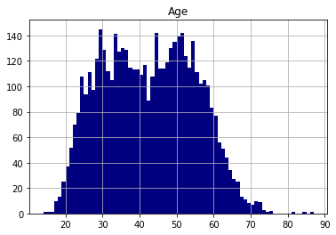

```python
drug.hist(column = "Age", bins = 73, color = 'navy') #min 14 y máx 87
```

### Sexo

```python
drug['Sex'] = drug['Sex'].replace('Unknown', "Male")
drug.groupby('Sex').size()
```

```
Sex
Female    1272
Male      3624
dtype: int64
```

```python
drug_sex = (drug.groupby("Sex").agg(frequency=("Sex", "count")).unstack())
drug_sex
```

```
           Sex
frequency  Female    1272
           Male      3624
dtype: int64
```

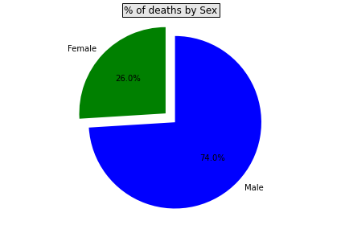

```python
Sex_values = ['Female', 'Male']
plt.pie(
   drug_sex,
    labels = Sex_values,
    colors = ('green', 'blue'),
    explode=(0, 0.15),
    shadow=False,
    startangle = 90,
    autopct='%1.1f%%',
)

plt.axis('equal')
plt.title('% of deaths by Sex', bbox={'facecolor':'0.9', 'pad':2})

plt.tight_layout()
plt.show()
```

### Raza

De la gráfica de **raza** podemos observar que la mayoría de las muertes se concentran en un grupo que destaca sobre los demás, el cual es el de la Raza Blanca, seguido por Hispanic White y Black.

```
       White                     79.146242 %
       Hispanic, White           10.682190 %
       Black                      8.374183 %
       Unknown                    0.428922 %
       Hispanic, Black            0.428922 %
       Asian, Other               0.367647 %
       Asian Indian               0.285948 %
       Other                      0.204248 %
       Chinese                    0.040850 %
       Native American, Other     0.020425 %
       Hawaiian                   0.020425 %
```

Pero, para poder contextualizar, lo ideal es exponer también el porcentaje de estos grupos sobre el total de la población.

En 2006 el estado contaba con una población de 3.504.809 personas, de las cuales:

```
        El 74,5% son blancos (europeos o descendientes de europeos).

        El 11,2% son latinos o hispanos

        El 9,5% son negros.

        El 3,3% son asiáticos.

        El resto lo conforman personas de otras razas.
```

**Fuente:** https://web.archive.org/web/20081211054741/http://factfinder.census.gov/servlet/STTable?_bm=y&-context=st&-qr_name=ACS_2006_EST_G00_S0501&-ds_name=ACS_2006_EST_G00_&-tree_id=306&-redoLog=false&-_caller=geoselect&-geo_id=04000US09&-format=&-_lang=en

```python
drug_race = (drug.groupby("Race").agg(frequency=("Race", "count")).unstack().sort_values(ascending=False))
drug_race/48.96
```

```
           Race
frequency  White                     79.146242
           Hispanic, White           10.682190
           Black                      8.374183
           Unknown                    0.428922
           Hispanic, Black            0.428922
           Asian, Other               0.367647
           Asian Indian               0.285948
           Other                      0.204248
           Chinese                    0.040850
           Native American, Other     0.020425
           Hawaiian                   0.020425
dtype: float64
```

```python
Race_values = ['White', 'Hispanic, White', 'Black', 'Unknown', 'Hispanic, Black', 'Asian, Other', 'Asian Indian', 'Other','Chinese', 'Native American, Other', 'Hawaiian']
Race_values
```

```
['White',
 'Hispanic, White',
 'Black',
 'Unknown',
 'Hispanic, Black',
 'Asian, Other',
 'Asian Indian',
 'Other',
 'Chinese',
 'Native American, Other',
 'Hawaiian']
```

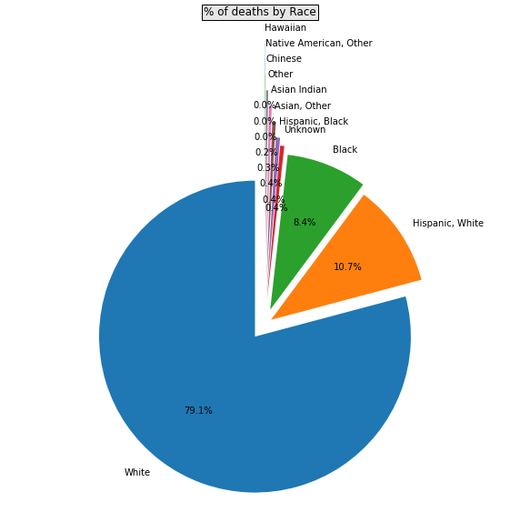

```python
plt.figure(figsize=(10,10))
plt.pie(
   drug_race,
    labels = Race_values,
    shadow=False,
    startangle = 90,
    explode=(0.1, 0.05, 0.10, 0.15, 0.2, 0.3, 0.4, 0.5, 0.6, 0.7, 0.8),
    autopct='%1.1f%%',
)

plt.axis('equal')
plt.title('% of deaths by Race',  bbox={'facecolor':'0.9', 'pad':2})
plt.figure(figsize=(10,10))
plt.tight_layout()
plt.show()
```

### Ciudad de Residencia

De la gráfica de **ResidenceCity** podemos observar una concentración de valores en las ciudades de:

[output not shown]

```python
drug_ResidenceCity = (drug.groupby("ResidenceCity").agg(EEUU =("ResidenceCity", "count")).unstack().sort_values(ascending=False))
drug_ResidenceCity = drug_ResidenceCity[1:50]
```

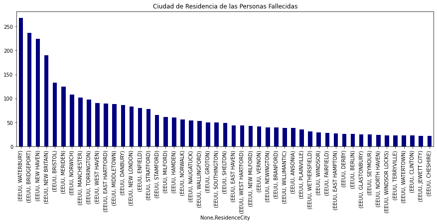

```python
drug_ResidenceCity.plot(figsize = (15,5),kind='bar', color = 'navy', title = 'Ciudad de Residencia de las Personas Fallecidas')
```